# Data Introperability in GEE

Kaitlin Walker (adapted from Jillian LaRoe and Julia Sullivan)

03 April, 2019

# 1 The in and out

In this excercise, we will discuss some of the options for moving data in and out of the Google Earth Engine (GEE) Code Editor. The processes surrounding this have been changing rapidly and as with most things it’s best to go directly to the docs. That information can be found [here](https://developers.google.com/earth-engine/importing)

As we will move vector data in and out of GEE for this lesson, we will briefly cover one method of importing and exporting data below.

## 1.1 Coordinate Reference System

First, it is important to note that the projection that GEE uses is **WGS 1984** EPSG:4326. Thus, all data needs to be imported with that same coordinate reference system. Some platforms might need more specific information. In the past we’ve had to use **WGS 1984 Web Auxiliary Sphere**. In general you should be fine working with unproject data in the WGS1984 geographic coordinate system.

## 1.2 Exporting out of GEE

There are multiple options to export data from GEE. Unlike nearly everyother process in GEE, exporting and importing data is slow. Expect small vector and tabular data to take multiple minutes. Large raster datasets can take hours and require a bit more tinkering on your end. We will not get into those details here.

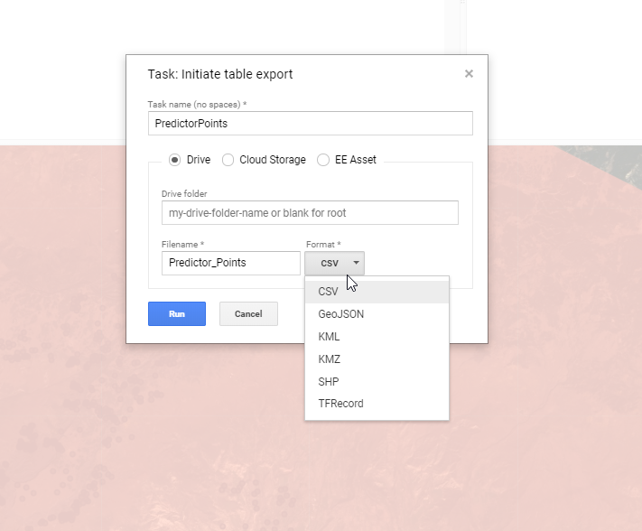

export options

You can export your feature to what ever datatype you desire. Exporting data as a .shp was added in 2018.

QGIS provides the option to load KML, KMZ, geoJson, and SHP, so visualizing and working with the data in a desktop GIS is a readily available option.

## 1.3 Fusion Tables

Come December 2019 Fusion Tables will no longer be support by Google. While the end of the line is forseeable for this datatype they do intergrate with GEE very well and will will be using them within this process.

A convenient way to convert from a shapefile to a Fusion Table is by using the website **“Shape Escape”**: shpescape.com. In the steps below, we walk through this process.

1. Copy all associated files (“.shp” “.shx” “.dbf” and “.prj”) to a new folder on your computer, and zip the folder.
2. Go to shpescape.com. Choose the “shp 2 fusion tables” option.
3. Select Continue.
4. Upoad your zipped folder, and submit.
5. Click the link to access your Fusion Table.
6. Once you have opened your table, click “Share” to choose sharing options or add access for specific people.

## 1.4 CSV or KML to Fusion Table

The following steps walk through how to convert CSV or KML data to a Fusion Table.  
1. Go to [this Link](https://support.google.com/fusiontables/answer/2571232?hl=en). Here, you can create a Fusion Table through Google Drive.  
2. Select “Create Fusion Table”.  
3. Select a .kml or .csv file type.  
4. Click “Share” to choose sharing options or add access for specific people.

## 1.5 Importing a Fusion Table into Google Earth Engine

Once you have created your fusion table, open it. Fusion Tables are stored on your Google Drive, and can be opened by right-clicking the file in your drive. Then, you can select **Open with > Fusion Tables**.

When you have opened your table, click the File tab, then the **About this Table** option. A new window will open which includes information such as the table ID. This is a specific ID that you can share with people or link in a GEE script in order to call upon this specific table. Copy this ID (highlight and right click to copy.)

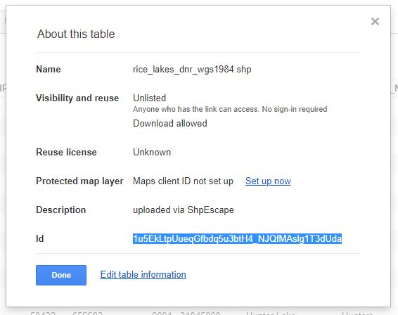

About This Table.

Next, go to your GEE script. Once here, you can paste in the table ID in order to reference this table.

The syntax for importing a table using a Fusion Table ID is as follows:

```javascript
var fc = ee.FeatureCollection('ft:1F4daSPf6KFxX8fM-mWi_ahqsd9Pgsw3FmCryDGID');
```

Here, you may paste in you table ID, and rename your variable.

Thus far, we have only created the variable that stores the data. If you want to add the data to the map, you can use the **Map.addLayer** function.

```javascript
Map.addLayer(fc,{},'import')
print(fc)
```

The first argument should be the name of the variable you created previously. In the third argument (in quatations), you can name the layer as you’d like it to appear under the Layers tab. The fourth argument specifies if you want the layer to automatically appear. “false” means that the layer will only appear on the map when toggled on, under the Layers tab, which appears after you have run the **Map.addLayer** function in the right corner of the map window. Specifying “true” means that the layer will initially appear automatically. Click **“Run”** to run the script:

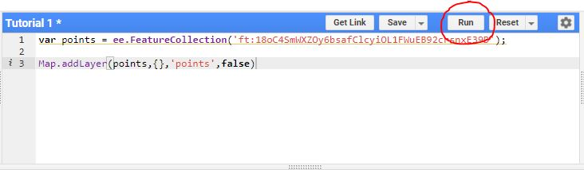

The “Run” Button.

Congratulations! You have now created a Fusion Table and imported your data into GEE.